# Aprendizaje Estadístico y Toma de Decisiones

Clasificación de Tumores según Datos de Mamografías - Código

Maria del Mar Bibiloni Femenias

En este documento se prentende mostrar todo el código utilizado para realizar el trabajo final de la asignatura Aprendizaje estadístico y toma de deciciones: *Clasificación de Tumores según Datos de Mamografías* .

**Nota:** No aparece texto explicativo sobre en análisi datos, sinó algunos comentarios para acompanyar el código que se aplica a cada caso. Así, el documento *TrabajoFinal_memoria_MBF.pdf* es el documento principal, con las explicaciones correspondientes.

## Preparación del dataset.

Los datos de mamografías de mujeres con tumores benignos y malignos se pueden descargar del repositiorio UCI, [aquí](http://archive.ics.uci.edu/ml/datasets/Mammographic+Mass).

Cargamos los datos.

```r
original_data= read.table("mammographic_masses.data.txt", sep=",", header=FALSE)
```

Nombramos las columnas.

```r
colnames(original_data) <- c("BIRADS", "Age", "Shape", "Margin", "Density", "Severity")
```

Vemos las primeras filas.

```r
head(original_data,10)
```

| BIRADS | Age | Shape | Margin | Density | Severity |
| --- | --- | --- | --- | --- | --- |
| 5 | 67 | 3 | 5 | 3 | 1 |
| 4 | 43 | 1 | 1 | ? | 1 |
| 5 | 58 | 4 | 5 | 3 | 1 |
| 4 | 28 | 1 | 1 | 3 | 0 |
| 5 | 74 | 1 | 5 | ? | 1 |
| 4 | 65 | 1 | ? | 3 | 0 |
| 4 | 70 | ? | ? | 3 | 0 |
| 5 | 42 | 1 | ? | 3 | 0 |
| 5 | 57 | 1 | 5 | 3 | 1 |
| 5 | 60 | ? | 5 | 1 | 1 |

Dimensiones.

```r
matrix(dim(original_data),nrow=2, ncol=1, dimnames=list(c("Observations: ","Predictors:"), ""))
```

```
##
## Observations:  961
## Predictors:      6
```

Excepto la variable **Age**, las variables son cualitativas.  
Veamos cuántos valores hay de cada tipo.

```r
apply(original_data[,-2], 2, function(x) table(x))
```

```
## $BIRADS
## x
##   ?   0   2   3   4   5  55   6
##   2   5  14  36 547 345   1  11
##
## $Shape
## x
##   ?   1   2   3   4
##  31 224 211  95 400
##
## $Margin
## x
##   ?   1   2   3   4   5
##  48 357  24 116 280 136
##
## $Density
## x
##   ?   1   2   3   4
##  76  16  59 798  12
##
## $Severity
## x
##   0   1
## 516 445
```

En BI-RADS nos aparece un valor 55, pero sabemos que la variable BI-RADS sólo toma valores en $\{1,2,3,4,5\}$. Así, podemos suponer que es un 5 o quitar la observación. La quitamos.

```r
data<-original_data
data=data[-which(original_data$BIRADS==55),]
```

Además tenemos 5 ceros pero, según la documentación, BI-RADS toma valores entre 1 y 5.  
Aún así, el valor cero si que existe en la classificación de BI-RADS.

Para evitar tener observaciones erroneas, los quitamos.  
(Si tubieramos más información sobre el data set se podría arreglar)

```r
data[which(data$BIRADS==0),]
```

|  | BIRADS | Age | Shape | Margin | Density | Severity |
| --- | --- | --- | --- | --- | --- | --- |
| 457 | 0 | 69 | 4 | 5 | 3 | 1 |
| 534 | 0 | 58 | 4 | 4 | 3 | 0 |
| 800 | 0 | 72 | 4 | 3 | 3 | 1 |
| 894 | 0 | 45 | 2 | 4 | 3 | 0 |
| 951 | 0 | 71 | 4 | 4 | 3 | 1 |

```r
data=data[-which(data$BIRADS==0),]
```

También hay BI-RADS tipo 6, aunque tampoco aparece en la documentación. Para que sea correcto, todos se deberían ser 1. Además, el 6 indica que se ha hecho biopsia y el estudio surge para evitar hacerla en casos que no sea necesario. Por este motivo, quitamos también éstas observaciones.

```r
data[which(data$BIRADS==6),]
```

|  | BIRADS | Age | Shape | Margin | Density | Severity |
| --- | --- | --- | --- | --- | --- | --- |
| 551 | 6 | 80 | 4 | 5 | 3 | 1 |
| 665 | 6 | 60 | 3 | 5 | 3 | 1 |
| 693 | 6 | 51 | 4 | 4 | 3 | 1 |
| 708 | 6 | 41 | 2 | 1 | 3 | 0 |
| 718 | 6 | 71 | 4 | 4 | 3 | 1 |
| 719 | 6 | 68 | 4 | 3 | 3 | 1 |
| 746 | 6 | 76 | 3 | ? | 3 | 0 |
| 785 | 6 | 63 | 1 | 1 | 3 | 0 |
| 825 | 6 | 40 | ? | 3 | 4 | 1 |
| 833 | 6 | 72 | 4 | 3 | 3 | 1 |

[output cut: 1 more lines]

```r
data<-data[-which(data$BIRADS==6),]
```

Ahora, veamos cuantos NaN tenemos por columna.

```r
#Cambiamos ? por NaN
data[data=="?"]<- NaN
apply(data, 2, function(x) sum(is.na(x)))
```

```
##   BIRADS      Age    Shape   Margin  Density Severity
##        2        5       30       47       76        0
```

Salvo la edad, no es conveniente cambiar los NaN por algun otro valor.  
Así, nos quedamos sólo con las observaciones completas.

```r
data <- data[complete.cases(data),]
dim(data)
```

```
## [1] 815   6
```

Finalmente, veamos como quedan distribuidos los datos.

```r
apply(data[,-2], 2, function(x) table(x))
```

```
## $BIRADS
## x
##   2   3   4   5
##   7  24 468 316
##
## $Shape
## x
##   1   2   3   4
## 189 178  79 369
##
## $Margin
## x
##   1   2   3   4   5
## 318  23 101 249 124
##
## $Density
## x
##   1   2   3   4
##  11  55 741   8
##
## $Severity
## x
##   0   1
## 423 392
```

Tal como sigue, R reconoce las variables como factores, pero para poder aplicar la mayoría de métodos, necesitamos que sean de tipo numérico.

```r
lapply(data[1,], data.class)
```

```
## $BIRADS
## [1] "factor"
##
## $Age
## [1] "factor"
##
## $Shape
## [1] "factor"
##
## $Margin
## [1] "factor"
##
## $Density
## [1] "factor"
##
## $Severity
## [1] "numeric"
```

Pasamos a numérico, menos la variable Severity.

```r
data <- as.data.frame(apply(data, 2, as.numeric))
data$Severity <- as.factor(data$Severity)
```

### Train-Test

Tomamos 2/3 de los datos aleatoriamente y los guardamos como train.  
La idea es no usar el conjunto restante (test) para entrenar ningún modelo y así evitar el overfitting. De esta manera, se usará para simular el error en *nuevos datos*.

```r
set.seed(1123)
train=sample(nrow(data), size = ceiling(2/3*nrow(data)) )
test=c(1:nrow(data))[-train]
```

En los datos originales hay una buena proporción de casos de tumor benigno y maligno, es decir, no es un problema no balanceado, por tanto, no hay que modificar la muestra.

Aún así, se debe comprobar si se mantiene, aproximadamente, la proporción en *test* y *train*.

```r
matrix(c( table(original_data$Severity)/nrow(original_data),
table(data[train,]$Severity)/length(train),
table(data[test,]$Severity)/length(test) ), nrow=3, ncol=2, byrow = TRUE,
dimnames=list(c("Original set ","Train set", "Test set"), c("Benign (0)","Malign(1)")) )
```

```
##               Benign (0) Malign(1)
## Original set   0.5369407 0.4630593
## Train set      0.5202206 0.4797794
## Test set       0.5166052 0.4833948
```

Se mantiene.  
Ya tenemos los conjuntos de entrenamiento y validación.

### Pair Plot

En esta sección, vamos a realizar un pair plot de las variables, con el objetivo de ver la relación entre las variables, dos a dos, y conocer un poco más el dataset.

En cada plot indicamos por colores si cada observación pertenece a la classe benigno o maligno. Además, sólo realizamos el plot sobre train (test sólo es para simular el error fuera de la muestra).

Para hacer el plot, Tratamos los datos como cotinuos (menos severity). Así, los puntos quedan dibujados sobre el plano.

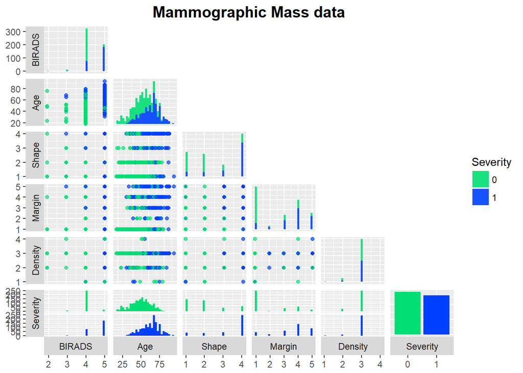

```r
library(ggplot2)
library(GGally)

pairplot <- ggpairs(data[train,],
                    title="Mammographic Mass data",
                    mapping=aes(colour = Severity),
                    upper="blank",
                    lower = list(continuous = wrap("points",alpha = 0.7)),
                    diag = list(continuous = wrap("barDiag", alpha=0.9)),
                    legend = 1,
                    switch = "both")+theme(plot.title=element_text(size = 15,face='bold',
                                                                   hjust=0.5))

for(i in 1:pairplot$nrow) {
  for(j in 1:pairplot$ncol){
    pairplot[i,j] <- pairplot[i,j] +
        scale_fill_manual(values=c("#01DF74", "#0040FF")) +
        scale_color_manual(values=c("#01DF74", "#0040FF"))
  }
}
pairplot
```

### Variables Dummy

Crear dummies:

```r
library("dummies")
data_dum <-dummy.data.frame(data, names=c("BIRADS","Shape", "Margin", "Density"), sep="_")
head(data_dum)
```

| BIRADS_2 | BIRADS_3 | BIRADS_4 | BIRADS_5 | Age | Shape_1 | Shape_2 | Shape_3 | Shape_4 | Margin_1 | Margin_2 | Margin_3 | Margin_4 | Margin_5 | Density_1 | Density_2 | Density_3 | Density_4 | Severity |
| --- | --- | --- | --- | --- | --- | --- | --- | --- | --- | --- | --- | --- | --- | --- | --- | --- | --- | --- |
| 0 | 0 | 0 | 1 | 67 | 0 | 0 | 1 | 0 | 0 | 0 | 0 | 0 | 1 | 0 | 0 | 1 | 0 | 1 |
| 0 | 0 | 0 | 1 | 58 | 0 | 0 | 0 | 1 | 0 | 0 | 0 | 0 | 1 | 0 | 0 | 1 | 0 | 1 |
| 0 | 0 | 1 | 0 | 28 | 1 | 0 | 0 | 0 | 1 | 0 | 0 | 0 | 0 | 0 | 0 | 1 | 0 | 0 |
| 0 | 0 | 0 | 1 | 57 | 1 | 0 | 0 | 0 | 0 | 0 | 0 | 0 | 1 | 0 | 0 | 1 | 0 | 1 |
| 0 | 0 | 0 | 1 | 76 | 1 | 0 | 0 | 0 | 0 | 0 | 0 | 1 | 0 | 0 | 0 | 1 | 0 | 1 |
| 0 | 1 | 0 | 0 | 42 | 0 | 1 | 0 | 0 | 1 | 0 | 0 | 0 | 0 | 0 | 0 | 1 | 0 | 1 |

Quitamos las columnas que serán la categoria referencia.

- BI_RADS: 2, benigno (ordinal-es el menor).
- Shape: 4, irregular (más común).
- Margin: 1, circunscrito (más común).
- Density: 3, baja (menor y además, el más común)

```r
refCategory=names(data_dum) %in% c("BIRADS_2", "Shape_4", "Margin_1", "Density_3")
data_dum = data_dum[, !refCategory]
head(data_dum)
```

| BIRADS_3 | BIRADS_4 | BIRADS_5 | Age | Shape_1 | Shape_2 | Shape_3 | Margin_2 | Margin_3 | Margin_4 | Margin_5 | Density_1 | Density_2 | Density_4 | Severity |
| --- | --- | --- | --- | --- | --- | --- | --- | --- | --- | --- | --- | --- | --- | --- |
| 0 | 0 | 1 | 67 | 0 | 0 | 1 | 0 | 0 | 0 | 1 | 0 | 0 | 0 | 1 |
| 0 | 0 | 1 | 58 | 0 | 0 | 0 | 0 | 0 | 0 | 1 | 0 | 0 | 0 | 1 |
| 0 | 1 | 0 | 28 | 1 | 0 | 0 | 0 | 0 | 0 | 0 | 0 | 0 | 0 | 0 |
| 0 | 0 | 1 | 57 | 1 | 0 | 0 | 0 | 0 | 0 | 1 | 0 | 0 | 0 | 1 |
| 0 | 0 | 1 | 76 | 1 | 0 | 0 | 0 | 0 | 1 | 0 | 0 | 0 | 0 | 1 |
| 1 | 0 | 0 | 42 | 0 | 1 | 0 | 0 | 0 | 0 | 0 | 0 | 0 | 0 | 1 |

## Mètodos de clasificación

Una vez tenemos los datos preparados, vamos a aplicar varios métodos de clasificación para crear diferentes modelos que permitan hacer predicciones sobre futuras mammografias.

### K-nearest neighbors

Para aplicar K-nearest neighbors, necesitamos especificar el número de vecinos (K). Así, usamos validación cruzada en train para elegir la mejor k.  
(Aquí no usamos las dummies)

```r
library(ISLR)
library(caret)
set.seed(5813)
cross_val <- trainControl(method="cv", number=10)

knn_fit <- train(Severity ~ ., data = data[train,], method = "knn", metric="Accuracy",  trControl = cross_val, tuneLength = 30)
knn_fit
```

```
## k-Nearest Neighbors
##
## 544 samples
##   5 predictor
##   2 classes: '0', '1'
##
## No pre-processing
## Resampling: Cross-Validated (10 fold)
## Summary of sample sizes: 490, 489, 490, 490, 490, 490, ...
## Resampling results across tuning parameters:
##
##   k   Accuracy   Kappa
##    5  0.7645791  0.5295722
##    7  0.7535017  0.5074057
##    9  0.7590236  0.5193047
```

[output cut: 30 more lines]

Selecciona 31, pero por la poca diferencia nos podriamos quedar con 5, ya que con menos vecinos evitamos no detectar “zonas” con pocos datos. Comparemos los modelos K=31 y K=5 en test.

- knn con k=31 para saber el error en test.

```r
library(class)
library('gmodels')
knn_k31_fit=knn(data[train,], data[test,], cl=data[train,]$Severity, k = 31)
ct_knn=CrossTable(x=data[test,]$Severity, y=knn_k31_fit)
```

```
##
##
##    Cell Contents
## |-------------------------|
## |                       N |
## | Chi-square contribution |
## |           N / Row Total |
## |           N / Col Total |
## |         N / Table Total |
## |-------------------------|
##
##
## Total Observations in Table:  271
##
##
##                       | knn_k31_fit
## data[test, ]$Severity |         0 |         1 | Row Total |
## ----------------------|-----------|-----------|-----------|
##                     0 |       105 |        35 |       140 |
##                       |    29.836 |    23.711 |           |
##                       |     0.750 |     0.250 |     0.517 |
##                       |     0.875 |     0.232 |           |
##                       |     0.387 |     0.129 |           |
## ----------------------|-----------|-----------|-----------|
##                     1 |        15 |       116 |       131 |
##                       |    31.886 |    25.340 |           |
##                       |     0.115 |     0.885 |     0.483 |
##                       |     0.125 |     0.768 |           |
##                       |     0.055 |     0.428 |           |
## ----------------------|-----------|-----------|-----------|
##          Column Total |       120 |       151 |       271 |
##                       |     0.443 |     0.557 |           |
## ----------------------|-----------|-----------|-----------|
##
##
```

Si nos fijamos en los tumores clasificados correctamente, el error es pequeño.

```r
error_knn31 = (ct_knn$t[2] + ct_knn$t[3])/length(test)
accuracy_knn31=1-error_knn31

accuracy_benign_knn31=(ct_knn$t[1])/(ct_knn$t[1] + ct_knn$t[3])
accuracy_malign_knn31=(ct_knn$t[4])/(ct_knn$t[2] + ct_knn$t[4])
```

```r
list_knn31=c(error_knn31, accuracy_knn31, accuracy_benign_knn31,accuracy_malign_knn31)

matrix(list_knn31, nrow=1, ncol=4,
dimnames=list(c("Knn (K=31)"),c("Error", "Accuracy", "Accuracy_benign", "Accuracy_malign")) )
```

```
##                Error  Accuracy Accuracy_benign Accuracy_malign
## Knn (K=31) 0.1845018 0.8154982            0.75       0.8854962
```

- knn con k=5 para saber el error en test.

```r
knn_k5_fit=knn(data[train,], data[test,], cl=data[train,]$Severity, k = 5)
ct_knn5=CrossTable(x=data[test,]$Severity, y=knn_k5_fit)
```

```
##
##
##    Cell Contents
## |-------------------------|
## |                       N |
## | Chi-square contribution |
## |           N / Row Total |
## |           N / Col Total |
## |         N / Table Total |
## |-------------------------|
##
##
## Total Observations in Table:  271
##
##
##                       | knn_k5_fit
## data[test, ]$Severity |         0 |         1 | Row Total |
## ----------------------|-----------|-----------|-----------|
##                     0 |       120 |        20 |       140 |
##                       |    40.456 |    37.855 |           |
##                       |     0.857 |     0.143 |     0.517 |
##                       |     0.916 |     0.143 |           |
##                       |     0.443 |     0.074 |           |
## ----------------------|-----------|-----------|-----------|
##                     1 |        11 |       120 |       131 |
##                       |    43.236 |    40.456 |           |
##                       |     0.084 |     0.916 |     0.483 |
##                       |     0.084 |     0.857 |           |
##                       |     0.041 |     0.443 |           |
## ----------------------|-----------|-----------|-----------|
##          Column Total |       131 |       140 |       271 |
##                       |     0.483 |     0.517 |           |
## ----------------------|-----------|-----------|-----------|
##
##
```

```r
error_knn5 = (ct_knn5$t[2] + ct_knn5$t[3])/length(test)
accuracy_knn5=1-error_knn5

accuracy_benign_knn5=(ct_knn5$t[1])/(ct_knn5$t[1] + ct_knn5$t[3])
accuracy_malign_knn5=(ct_knn5$t[4])/(ct_knn5$t[2] + ct_knn5$t[4])

list_knn5=c(error_knn5, accuracy_knn5, accuracy_benign_knn5,accuracy_malign_knn5)

matrix(c(list_knn31,list_knn5), nrow=2, ncol=4, byrow = TRUE,
dimnames=list(c("Knn (K=31)","Knn (K=5)"),c("Error", "Accuracy", "Accuracy_benign", "Accuracy_malign")) )
```

```
##                Error  Accuracy Accuracy_benign Accuracy_malign
## Knn (K=31) 0.1845018 0.8154982       0.7500000       0.8854962
## Knn (K=5)  0.1143911 0.8856089       0.8571429       0.9160305
```

Nos quedamos con k=5!

### Logistic regression

Estimaremos el modelo con todas las variables dummies.

```r
logReg <- glm(Severity ~.,family=binomial(link='logit'),data=data_dum[train,])
logReg$coefficients
```

```
##  (Intercept)     BIRADS_3     BIRADS_4     BIRADS_5          Age
## -17.83915110  14.98758698  14.18573252  16.47738735   0.05608061
##      Shape_1      Shape_2      Shape_3     Margin_2     Margin_3
##  -1.19351332  -1.40851600  -0.76915994   0.70441571   0.27308474
##     Margin_4     Margin_5    Density_1    Density_2    Density_4
##   0.70573668   0.52628792   0.23960310  -0.27047293  -1.98147844
```

Para cada uno de los coeficientes $\beta_i$, realizamos el siguiente contraste de significación

$$\left\{ \begin{array}{ll}
H_0:& \beta_i = 0,\\
H_1:& \beta_i \not=0,
\end{array}\right.$$

al nivel de significación $\alpha=0.05$.

```r
summary(logReg)
```

```
##
## Call:
## glm(formula = Severity ~ ., family = binomial(link = "logit"),
##     data = data_dum[train, ])
##
## Deviance Residuals:
##     Min       1Q   Median       3Q      Max
## -2.5252  -0.5484  -0.2153   0.4740   2.5073
##
## Coefficients:
##              Estimate Std. Error z value Pr(>|z|)
## (Intercept) -17.83915  639.30081  -0.028 0.977739
## BIRADS_3     14.98759  639.30092   0.023 0.981296
## BIRADS_4     14.18573  639.30046   0.022 0.982297
## BIRADS_5     16.47739  639.30050   0.026 0.979438
## Age           0.05608    0.01089   5.149 2.62e-07 ***
## Shape_1      -1.19351    0.43498  -2.744 0.006073 **
## Shape_2      -1.40852    0.39517  -3.564 0.000365 ***
## Shape_3      -0.76916    0.39998  -1.923 0.054478 .
## Margin_2      0.70442    0.71611   0.984 0.325279
## Margin_3      0.27308    0.46315   0.590 0.555445
## Margin_4      0.70574    0.39507   1.786 0.074038 .
## Margin_5      0.52629    0.50684   1.038 0.299100
## Density_1     0.23960    0.94960   0.252 0.800793
## Density_2    -0.27047    0.47646  -0.568 0.570257
## Density_4    -1.98148    1.41175  -1.404 0.160450
## ---
## Signif. codes:  0 '***' 0.001 '**' 0.01 '*' 0.05 '.' 0.1 ' ' 1
##
## (Dispersion parameter for binomial family taken to be 1)
##
##     Null deviance: 753.25  on 543  degrees of freedom
## Residual deviance: 417.39  on 529  degrees of freedom
## AIC: 447.39
##
## Number of Fisher Scoring iterations: 14
```

Ningún coeficiente del grupo BI-RADS, Density o Margin es significativo.  
Veamos la matriz de correlaciones.

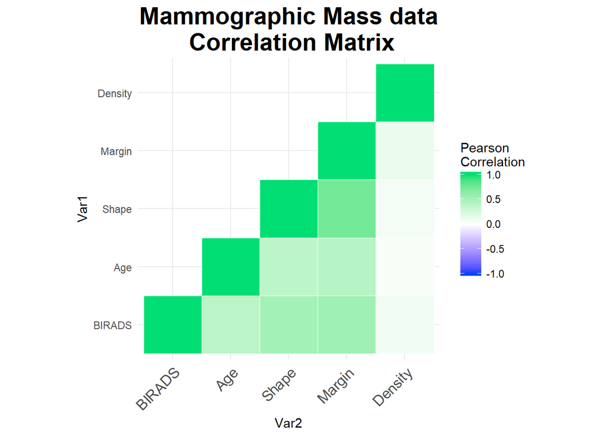

```r
#Correlation matrix
cormat = cor(data[,-6])
get_upper_tri <- function(cormat){
  cormat[lower.tri(cormat)]<- NA
  return(cormat)
}
library(reshape2)
upper_tri <-get_upper_tri(cormat)
melted_cormat <- melt(upper_tri, na.rm = TRUE)
#Plot
library(ggplot2)
ggplot(data = melted_cormat, aes(Var2, Var1, fill = value))+
 geom_tile(color = "white")+
 scale_fill_gradient2(low = "#0040FF", high = "#01DF74", mid = "white",
   midpoint = 0, limit = c(-1,1), space = "Lab",
   name="Pearson\nCorrelation") +
  labs(title= "Mammographic Mass data\n Correlation Matrix")+
  theme_minimal()+
 theme(axis.text.x = element_text(angle = 45, vjust = 1,
    size = 12, hjust = 1))+
 coord_fixed()+theme(plot.title=element_text(size = 20,face='bold',hjust=0.5))
```

Density no está muy correlacionada con ninguna otra variable.  
Eliminamos las variables BI-RADS y repetimos el contraste de significación de los coeficientes ($\alpha=0.05$).

```r
data_logReg = data_dum[,4:15]
logReg_notBR <- glm(Severity ~.,family=binomial(link='logit'),data=data_logReg[train,])
logReg_notBR$coefficients
```

```
## (Intercept)         Age     Shape_1     Shape_2     Shape_3    Margin_2
## -3.32680639  0.05994581 -1.58906897 -1.85339179 -1.00111280  1.24621027
##    Margin_3    Margin_4    Margin_5   Density_1   Density_2   Density_4
##  0.74509264  1.32345565  1.48200269  0.60476907 -0.33718731 -0.93956299
```

```r
summary(logReg_notBR)
```

```
##
## Call:
## glm(formula = Severity ~ ., family = binomial(link = "logit"),
##     data = data_logReg[train, ])
##
## Deviance Residuals:
##     Min       1Q   Median       3Q      Max
## -2.2924  -0.5945  -0.2325   0.6718   2.5236
##
## Coefficients:
##              Estimate Std. Error z value Pr(>|z|)
## (Intercept) -3.326806   0.624663  -5.326 1.01e-07 ***
## Age          0.059946   0.009722   6.166 7.00e-10 ***
## Shape_1     -1.589069   0.393278  -4.041 5.33e-05 ***
## Shape_2     -1.853392   0.354864  -5.223 1.76e-07 ***
## Shape_3     -1.001113   0.349052  -2.868 0.004130 **
## Margin_2     1.246210   0.645805   1.930 0.053644 .
## Margin_3     0.745093   0.412151   1.808 0.070635 .
## Margin_4     1.323456   0.352305   3.757 0.000172 ***
## Margin_5     1.482003   0.444794   3.332 0.000863 ***
## Density_1    0.604769   0.852702   0.709 0.478176
## Density_2   -0.337187   0.428348  -0.787 0.431176
## Density_4   -0.939563   1.421256  -0.661 0.508562
## ---
## Signif. codes:  0 '***' 0.001 '**' 0.01 '*' 0.05 '.' 0.1 ' ' 1
##
## (Dispersion parameter for binomial family taken to be 1)
##
##     Null deviance: 753.25  on 543  degrees of freedom
## Residual deviance: 485.62  on 532  degrees of freedom
## AIC: 509.62
##
## Number of Fisher Scoring iterations: 5
```

Hagamos el contraste *Likelihood ratio tests* para saber que modelo explica mejor las variables.

$$\left\{ \begin{array}{ll}
H_0:& \mbox{El modelo sin variables BI-RADS es verdadero},\\
H_1:& \mbox{El modelo completo es verdadero}.
\end{array}\right.$$

```r
anova(logReg_notBR, logReg, test="LRT")
```

| Resid. Df | Resid. Dev | Df | Deviance | Pr(>Chi) |
| --- | --- | --- | --- | --- |
| 532 | 485.6158 | NA | NA | NA |
| 529 | 417.3913 | 3 | 68.22454 | 1.024167e-14 |

Rechazamos, por tanto, seleccionamos el modelo con las variables BIRAD.  
Además, comparemos los errores.

Càlculo del error en test para el modelo completo.

```r
logReg_fit_0 <- predict(logReg,newdata=data_dum[test,-15], type='response')

#>=0.5 --> 1; <0.5 --> 0
logReg_fit_0  <- ifelse(logReg_fit_0  >= 0.5,1,0)

error_logReg_0 <- mean(logReg_fit_0   != data_dum[test,]$Severity)
accuracy_logReg_0=1-error_logReg_0

ct_logReg_0=CrossTable(x=data[test,]$Severity, y=logReg_fit_0)
```

```
##
##
##    Cell Contents
## |-------------------------|
## |                       N |
## | Chi-square contribution |
## |           N / Row Total |
## |           N / Col Total |
## |         N / Table Total |
## |-------------------------|
##
##
## Total Observations in Table:  271
##
##
##                       | logReg_fit_0
## data[test, ]$Severity |         0 |         1 | Row Total |
## ----------------------|-----------|-----------|-----------|
##                     0 |       115 |        25 |       140 |
##                       |    35.090 |    31.878 |           |
##                       |     0.821 |     0.179 |     0.517 |
##                       |     0.891 |     0.176 |           |
##                       |     0.424 |     0.092 |           |
## ----------------------|-----------|-----------|-----------|
##                     1 |        14 |       117 |       131 |
##                       |    37.501 |    34.068 |           |
##                       |     0.107 |     0.893 |     0.483 |
##                       |     0.109 |     0.824 |           |
##                       |     0.052 |     0.432 |           |
## ----------------------|-----------|-----------|-----------|
##          Column Total |       129 |       142 |       271 |
##                       |     0.476 |     0.524 |           |
## ----------------------|-----------|-----------|-----------|
##
##
```

```r
accuracy_benign_logReg_0=(ct_logReg_0$t[1])/(ct_logReg_0$t[1] + ct_logReg_0$t[3])
accuracy_malign_logReg_0= (ct_logReg_0$t[4])/(ct_logReg_0$t[2] + ct_logReg_0$t[4])

list_logReg_0=c(error_logReg_0, accuracy_logReg_0, accuracy_benign_logReg_0,accuracy_malign_logReg_0)
```

Càlculo del error en test para el modelo sin las variables BR (BIRADS).

```r
logReg_notBR_fit <- predict(logReg_notBR,newdata=data_logReg[test,-12], type='response')

#>=0.5 --> 1; <0.5 --> 0
logReg_notBR_fit  <- ifelse(logReg_notBR_fit  >= 0.5,1,0)

error_logReg <- mean(logReg_notBR_fit  != data_logReg[test,]$Severity)
accuracy_logReg = 1-error_logReg
ct_logReg=CrossTable(x=data_logReg[test,]$Severity, y=logReg_notBR_fit)
```

```
##
##
##    Cell Contents
## |-------------------------|
## |                       N |
## | Chi-square contribution |
## |           N / Row Total |
## |           N / Col Total |
## |         N / Table Total |
## |-------------------------|
##
##
## Total Observations in Table:  271
##
##
##                              | logReg_notBR_fit
## data_logReg[test, ]$Severity |         0 |         1 | Row Total |
## -----------------------------|-----------|-----------|-----------|
##                            0 |       108 |        32 |       140 |
##                              |    33.106 |    26.705 |           |
##                              |     0.771 |     0.229 |     0.517 |
##                              |     0.893 |     0.213 |           |
##                              |     0.399 |     0.118 |           |
## -----------------------------|-----------|-----------|-----------|
##                            1 |        13 |       118 |       131 |
##                              |    35.380 |    28.540 |           |
##                              |     0.099 |     0.901 |     0.483 |
##                              |     0.107 |     0.787 |           |
##                              |     0.048 |     0.435 |           |
## -----------------------------|-----------|-----------|-----------|
##                 Column Total |       121 |       150 |       271 |
##                              |     0.446 |     0.554 |           |
## -----------------------------|-----------|-----------|-----------|
##
##
```

```r
accuracy_benign_logReg=(ct_logReg$t[1])/(ct_logReg$t[1] + ct_logReg$t[3])
accuracy_malign_logReg= (ct_logReg$t[4])/(ct_logReg$t[2] + ct_logReg$t[4])

list_logReg=c(error_logReg, accuracy_logReg, accuracy_benign_logReg,accuracy_malign_logReg)
```

Comparación.

```r
matrix(c(list_logReg_0, list_logReg), nrow=2, ncol=4, byrow=TRUE,
dimnames=list(c("Logistic Reg. (All)", "Log Reg. (Not BR)"), c("Error", "Accuracy", "Accuracy_benign", "Accuracy_malign")) )
```

```
##                         Error  Accuracy Accuracy_benign Accuracy_malign
## Logistic Reg. (All) 0.1439114 0.8560886       0.8214286       0.8931298
## Log Reg. (Not BR)   0.1660517 0.8339483       0.7714286       0.9007634
```

**Nota:** No solo buscamos un modelo que reduzca el error de test, sinó uno que reduzca el número de pacientes que se realizan una biopsia innecesária (falsos positivos). Por otra parte, recordemos que tratamos datos de cáncer y, por tanto, no queremos tumores malignos no seleccionados (falsos negativos).

### Árboles de clasificación

Para los árboles de clasificación no es necesario usar las variables dummies.

Antes de seleccionar los mejores parámetros, probemos el método.

```r
require(ISLR)
require(tree)
```

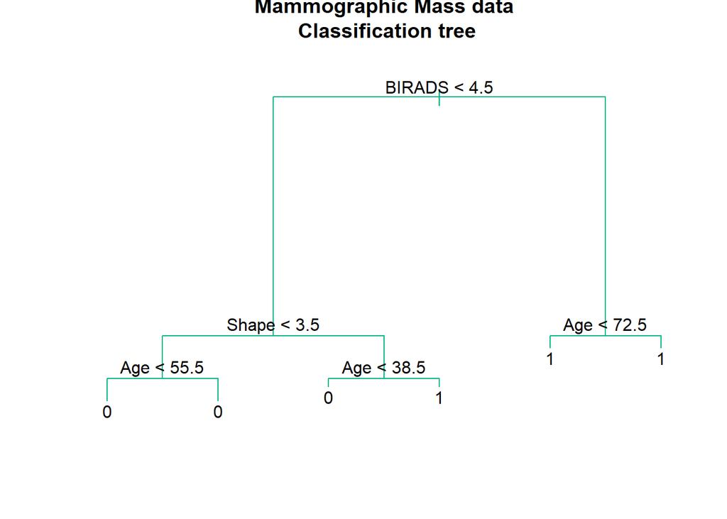

```r
tree=tree(Severity ~. ,data=data[train,])
plot(tree, col="#04B486")
title(main = "Mammographic Mass data\n Classification tree\n \n ")
text(tree,pretty=0)
```

Ahora, validación cruzada para elegir la profundidad.

```r
set.seed(555)
tree_cv=cv.tree(tree,FUN=prune.misclass, K=10)
tree_cv
```

```
## $size
## [1] 6 4 3 2 1
##
## $dev
## [1] 104 104 103 105 261
##
## $k
## [1] -Inf    0    5    6  160
##
## $method
## [1] "misclass"
##
## attr(,"class")
## [1] "prune"         "tree.sequence"
```

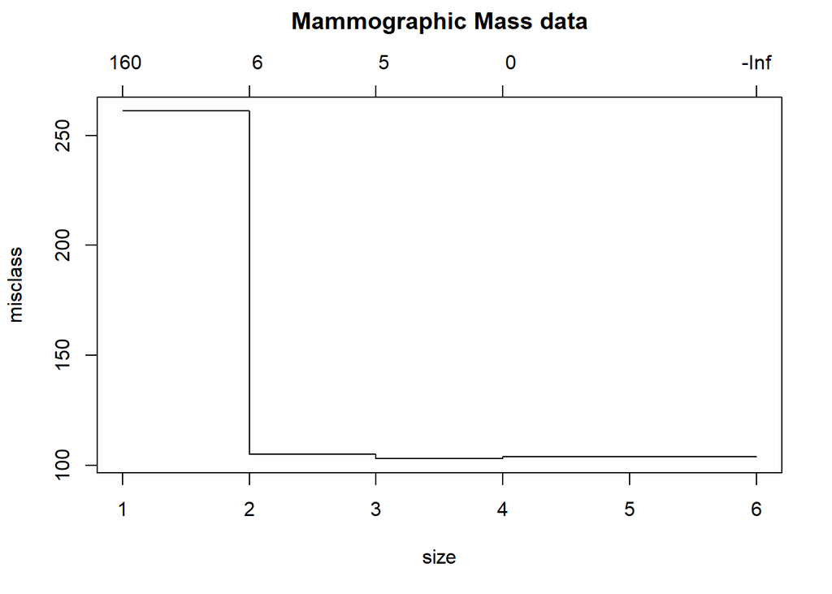

```r
plot(tree_cv)
title(main = "Mammographic Mass data\n \n ")
```

Nos quedamos con 3 de profundidad

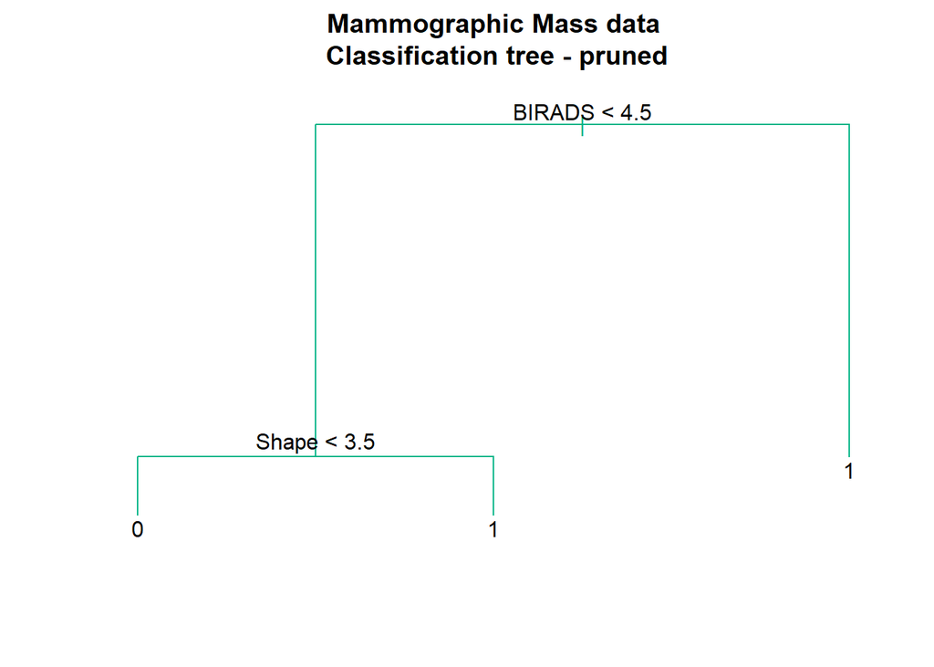

```r
prune_tree=prune.misclass(tree,best=3)
plot(prune_tree, col="#04B486")
title(main = "Mammographic Mass data\n Classification tree - pruned\n")
text(prune_tree,pretty=0)
```

Error.

```r
tree_fit=predict(prune_tree,data[test,],type="class")
ct_tree=with(data[test,],table(tree_fit,Severity))
ct_tree
```

```
##         Severity
## tree_fit   0   1
##        0 107   6
##        1  33 125
```

```r
error_tree=(ct_tree[1,2]+ct_tree[2,1])/length(test)
accuracy_tree=1-error_tree

accuracy_benign_tree=(ct_tree[1,1])/(ct_tree[1,1] + ct_tree[2,1])
accuracy_malign_tree=(ct_tree[2,2])/(ct_tree[1,2] + ct_tree[2,2])

list_tree=c(error_tree, accuracy_tree, accuracy_benign_tree,accuracy_malign_tree)

matrix(list_tree, nrow=1, ncol=4,
dimnames=list(c("Tree (d=3)"),c("Error", "Accuracy", "Accuracy_benign", "Accuracy_malign")) )
```

```
##                Error  Accuracy Accuracy_benign Accuracy_malign
## Tree (d=3) 0.1439114 0.8560886       0.7642857       0.9541985
```

### Random Forests

```r
require(randomForest)
require(MASS)
```

Primero, veamos que obtenemos creando 1000 muestras de Bootstrap y usando los parámetros por defecto: mtry$=\sqrt(p)$, donde $p$ es el númro de predictores.

```r
set.seed(1515)
rForest=randomForest(Severity~.,data=data[train,],ntree=1000)
rForest
```

```
##
## Call:
##  randomForest(formula = Severity ~ ., data = data[train, ], ntree = 1000)
##                Type of random forest: classification
##                      Number of trees: 1000
## No. of variables tried at each split: 2
##
##         OOB estimate of  error rate: 20.4%
## Confusion matrix:
##     0   1 class.error
## 0 227  56   0.1978799
## 1  55 206   0.2107280
```

Notemos que en cada paso toma 2 variables aleatóriamente. Como tenemos el conjunto de test, calculamos el error en lugar de fijar-nos en la estimación de OOB.

Error en test.

```r
rForest_fit=predict(rForest,data[test,])
ct_randForest=with(data[test,],table(rForest_fit,Severity))
ct_randForest
```

```
##            Severity
## rForest_fit   0   1
##           0 116  12
##           1  24 119
```

```r
error_randForest=(ct_randForest[1,2]+ct_randForest[2,1])/length(test)
accuracy_randForest=1-error_randForest

accuracy_benign_randForest=(ct_randForest[1,1])/(ct_randForest[1,1] + ct_randForest[2,1])
accuracy_malign_randForest=(ct_randForest[2,2])/(ct_randForest[1,2] + ct_randForest[2,2])

list_rForest=c(error_randForest, accuracy_randForest, accuracy_benign_randForest,accuracy_malign_randForest)
matrix(list_rForest, nrow=1, ncol=4,
dimnames=list(c("Random Forest (mtry 2)"),c("Error", "Accuracy", "Accuracy_benign", "Accuracy_malign")) )
```

```
##                            Error  Accuracy Accuracy_benign Accuracy_malign
## Random Forest (mtry 2) 0.1328413 0.8671587       0.8285714       0.9083969
```

Ahora, nos podriamos preguntar si tomar 2 variables a cada paso es suficiente o no.

Validación cruzada para escoger mtry.

```r
set.seed(1717)
cross_val_randForest<- trainControl(method="cv", number=10)

df_mtry=as.data.frame(matrix(c(1,2,3,4,5), nrow=5, ncol=1))
names(df_mtry)=c("mtry")

randForest_fit_cv <- train(Severity ~ ., data = data[train,], method = "rf", metric="Accuracy", trControl = cross_val_randForest, tuneGrid = df_mtry )

randForest_fit_cv
```

```
## Random Forest
##
## 544 samples
##   5 predictor
##   2 classes: '0', '1'
##
## No pre-processing
## Resampling: Cross-Validated (10 fold)
## Summary of sample sizes: 490, 489, 490, 489, 489, 490, ...
## Resampling results across tuning parameters:
##
##   mtry  Accuracy   Kappa
##   1     0.8179125  0.6356867
##   2     0.8031987  0.6057419
##   3     0.7774074  0.5538201
##   4     0.7626599  0.5242116
##   5     0.7571717  0.5128120
##
## Accuracy was used to select the optimal model using the largest value.
## The final value used for the model was mtry = 1.
```

```r
randForest_fit_cv$bestTune
```

| mtry |
| --- |
| 1 |

Tomamos mtry=1.

```r
set.seed(1919)
rForest1=randomForest(Severity~.,data=data[train,],ntree=1000, mtry=1)
rForest_fit1=predict(rForest1,data[test,])
ct_randForest1=with(data[test,],table(rForest_fit1,Severity))
ct_randForest1
```

```
##             Severity
## rForest_fit1   0   1
##            0 113  10
##            1  27 121
```

```r
error_randForest1=(ct_randForest1[1,2]+ct_randForest1[2,1])/length(test)
accuracy_randForest1=1-error_randForest1

accuracy_benign_randForest1=(ct_randForest1[1,1])/(ct_randForest1[1,1] + ct_randForest1[2,1])
accuracy_malign_randForest1=(ct_randForest1[2,2])/(ct_randForest1[1,2] + ct_randForest1[2,2])

list_rForest1=c(error_randForest1, accuracy_randForest1, accuracy_benign_randForest1,accuracy_malign_randForest1)
matrix(list_rForest1, nrow=1, ncol=4,
dimnames=list(c("Random Forest (mtry 1)"),c("Error", "Accuracy", "Accuracy_benign", "Accuracy_malign")) )
```

```
##                            Error  Accuracy Accuracy_benign Accuracy_malign
## Random Forest (mtry 1) 0.1365314 0.8634686       0.8071429       0.9236641
```

### Boosting

```r
require(gbm)
```

Antes de buscar los mejores parámetros, hacemos una prueba del método.

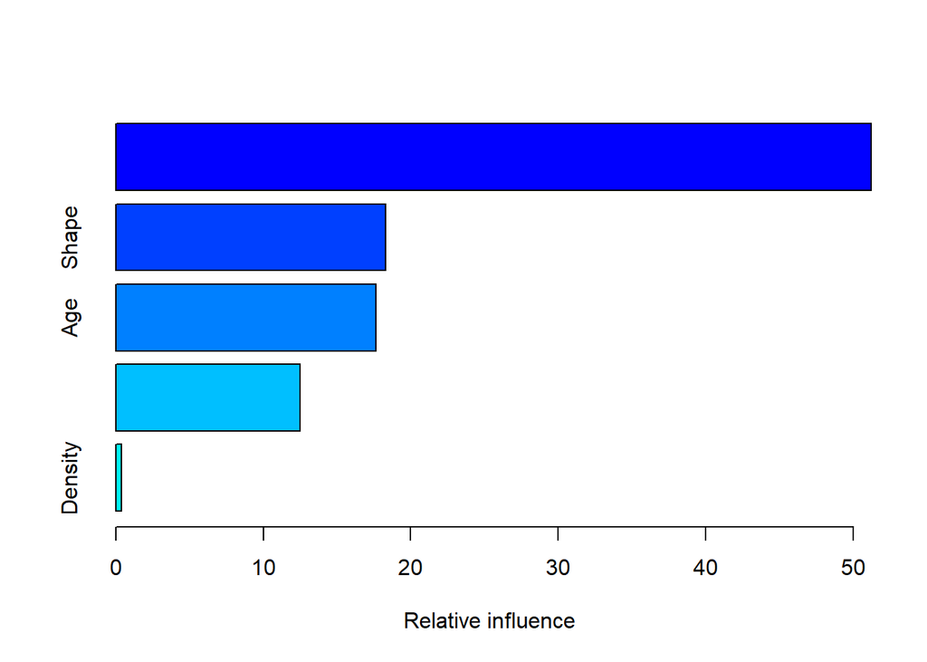

| var | rel.inf |
| --- | --- |
| BIRADS | 51.2248522 |
| Shape | 18.2783421 |
| Age | 17.6284409 |
| Margin | 12.4853445 |
| Density | 0.3830204 |

```r
#hay problemas con as.factor y gbm
data_gbm=data
data_gbm$Severity = as.character(data_gbm$Severity)

set.seed(1222)
boost = gbm(Severity~. , distribution = "bernoulli", data = data_gbm[train,],
               n.trees = 1000, shrinkage = 0.01)
summary(boost)
```

Error en Test.

```r
boost_pred = predict(object = boost, newdata = data_gbm[test,], n.trees = 1000, type = "response")
#>=0.5 --> 1; <0.5 --> 0
boost_pred   <- ifelse(boost_pred  >= 0.5,1,0)

ct_boost=with(data[test,],table(boost_pred,Severity))
ct_boost
```

```
##           Severity
## boost_pred   0   1
##          0 120  16
##          1  20 115
```

```r
error_boost=(ct_boost[1,2]+ct_boost[2,1])/length(test)
accuracy_boost=1-error_boost

accuracy_benign_boost=(ct_boost[1,1])/(ct_boost[1,1] + ct_boost[2,1])
accuracy_malign_boost=(ct_boost[2,2])/(ct_boost[1,2] + ct_boost[2,2])

list_boost=c(error_boost, accuracy_boost, accuracy_benign_boost,accuracy_malign_boost)
matrix(list_boost, nrow=1, ncol=4,
dimnames=list(c("Boosting (shrinkage 0.01)"),c("Error", "Accuracy", "Accuracy_benign", "Accuracy_malign")) )
```

```
##                               Error  Accuracy Accuracy_benign
## Boosting (shrinkage 0.01) 0.1328413 0.8671587       0.8571429
##                           Accuracy_malign
## Boosting (shrinkage 0.01)       0.8778626
```

Veamos si podemos mejorar el modelo variando los parámetros.

Validación cruzada.

```r
set.seed(8799)
cross_val_boost <- trainControl(method="cv", number=10)

boost_fit <- train(Severity ~ ., data = data_gbm[train,], method = "gbm", distribution = "bernoulli", metric="Accuracy", trControl = cross_val_boost, tuneLength = 10)
```

```r
boost_fit$bestTune
```

| n.trees | interaction.depth | shrinkage | n.minobsinnode |
| --- | --- | --- | --- |
| 50 | 2 | 0.1 | 10 |

Seleccionamos estos parámetros y calculamos el error en test.

```r
set.seed(3573)
boost = gbm(Severity~. , distribution = "bernoulli", data = data_gbm[train,],
               n.trees = 50, shrinkage = 0.1, interaction.depth = 2, n.minobsinnode = 10)
boost_pred = predict(object = boost, newdata = data_gbm[test,], n.trees = 50, type = "response")
boost_pred   <- ifelse(boost_pred  >= 0.5,1,0)

ct_boost=with(data[test,],table(boost_pred,Severity))
ct_boost
```

```
##           Severity
## boost_pred   0   1
##          0 121  14
##          1  19 117
```

```r
error_boost=(ct_boost[1,2]+ct_boost[2,1])/length(test)
accuracy_boost=1-error_boost

accuracy_benign_boost=(ct_boost[1,1])/(ct_boost[1,1] + ct_boost[2,1])
accuracy_malign_boost=(ct_boost[2,2])/(ct_boost[1,2] + ct_boost[2,2])

list_boost=c(error_boost, accuracy_boost, accuracy_benign_boost,accuracy_malign_boost)
matrix(list_boost, nrow=1, ncol=4,
dimnames=list(c("Boosting (nt=50, d=2, shr=0.1, n.mino=10)"),c("Error", "Accuracy", "Accuracy_benign", "Accuracy_malign")) )
```

```
##                                               Error  Accuracy
## Boosting (nt=50, d=2, shr=0.1, n.mino=10) 0.1217712 0.8782288
##                                           Accuracy_benign Accuracy_malign
## Boosting (nt=50, d=2, shr=0.1, n.mino=10)       0.8642857       0.8931298
```

### Clustering para clasificación

Aunque el clustering es para aprendizaje no supervisado, en este apartado vamos a aplicar el algoritmo kmeans, con k=2, con la idea de ver si los datos se dividen de forma *natural* según benign/malign.

Para el clustering, escalamos las variables.

Nota: para hacer k-means quitamos la columna Severity; por tanto, no hace falta dividir el conjunto en train o test. Para comparar los modelos, sí que calculamos el error sólo en test.

```r
data_clust=data
data_clust[,-6]=apply(data[,-6], 2, function(x) scale(x))

set.seed(2222)
kmeans_sc = kmeans(data_clust[,-6], centers=2)
ct_kmeans=table(kmeans_sc$cluster[test], data_clust[test,]$Severity)
ct_kmeans
```

```
##
##       0   1
##   1  35 124
##   2 105   7
```

```r
#Suponemos 1->1; 2->0

error_kmeans=(ct_kmeans[1,1]+ct_kmeans[2,2])/length(test)
accuracy_kmeans=1-error_kmeans

accuracy_benign_kmeans=(ct_kmeans[2,1])/(ct_kmeans[2,1] + ct_kmeans[1,1])
accuracy_malign_kmeans=(ct_kmeans[1,2])/(ct_kmeans[1,2] + ct_kmeans[2,2])

list_kmeans=c(error_kmeans, accuracy_kmeans, accuracy_benign_kmeans,accuracy_malign_kmeans)
matrix(list_kmeans, nrow=1, ncol=4,
dimnames=list(c("kmeans (scaled)"),c("Error", "Accuracy", "Accuracy_benign", "Accuracy_malign")) )
```

```
##                     Error  Accuracy Accuracy_benign Accuracy_malign
## kmeans (scaled) 0.1549815 0.8450185            0.75       0.9465649
```

## Comparación

```r
matrix(c(list_knn31,list_knn5, list_logReg_0, list_logReg, list_tree, list_rForest,
         list_rForest1, list_boost, list_kmeans), nrow=9, ncol=4, byrow=TRUE,
       dimnames=list(c("knn (K=31)","knn (K=5)","Logistic Reg. (All)", "Log Reg. (Not BR)",
                       "Tree (d=3)","Random Forest (mtry 2)", "Random Forest (mtry 1)",
                       "Boosting (nt=50, d=2, shr=0.1, n.mino=10)", "kmeans (scaled)"),
                     c("Error", "Accuracy", "Accuracy_benign", "Accuracy_malign")) )
```

```
##                                               Error  Accuracy
## knn (K=31)                                0.1845018 0.8154982
## knn (K=5)                                 0.1143911 0.8856089
## Logistic Reg. (All)                       0.1439114 0.8560886
## Log Reg. (Not BR)                         0.1660517 0.8339483
## Tree (d=3)                                0.1439114 0.8560886
## Random Forest (mtry 2)                    0.1328413 0.8671587
## Random Forest (mtry 1)                    0.1365314 0.8634686
## Boosting (nt=50, d=2, shr=0.1, n.mino=10) 0.1217712 0.8782288
## kmeans (scaled)                           0.1549815 0.8450185
##                                           Accuracy_benign Accuracy_malign
## knn (K=31)                                      0.7500000       0.8854962
## knn (K=5)                                       0.8571429       0.9160305
## Logistic Reg. (All)                             0.8214286       0.8931298
## Log Reg. (Not BR)                               0.7714286       0.9007634
## Tree (d=3)                                      0.7642857       0.9541985
## Random Forest (mtry 2)                          0.8285714       0.9083969
## Random Forest (mtry 1)                          0.8071429       0.9236641
## Boosting (nt=50, d=2, shr=0.1, n.mino=10)       0.8642857       0.8931298
## kmeans (scaled)                                 0.7500000       0.9465649
```

## Modificación sobre Age

En esta sección tomamos los dos mejores modelos, según nuestros datos, y los aplicamos al dataset con log(data$Age) para reducir su peso.

```r
data_logA=data
data_logA$Age=log(data$Age)
```

- knn

Elegir la mejor k con validación cruzada 10-veces.

```r
set.seed(1573)
cross_val_logA <- trainControl(method="cv", number=10)

knn_fit_logA <- train(Severity ~ ., data = data_logA[train,], method = "knn", metric="Accuracy",  trControl = cross_val_logA, tuneLength =30)
knn_fit_logA
```

```
## k-Nearest Neighbors
##
## 544 samples
##   5 predictor
##   2 classes: '0', '1'
##
## No pre-processing
## Resampling: Cross-Validated (10 fold)
## Summary of sample sizes: 490, 489, 490, 489, 489, 489, ...
## Resampling results across tuning parameters:
##
##   k   Accuracy   Kappa
##    5  0.7869360  0.5726107
##    7  0.7978788  0.5944857
##    9  0.7924916  0.5838379
```

[output cut: 30 more lines]

Selecciona K=35; nos quedamo con k=27 (el segundo mejor), ya que k=35 són muchos vecinos.

```r
knn_fit_logA=knn(data_logA[train,], data_logA[test,], cl=data_logA[train,]$Severity, k = 27)
ct_knn_logA=CrossTable(x=data_logA[test,]$Severity, y=knn_fit_logA)
```

```
##
##
##    Cell Contents
## |-------------------------|
## |                       N |
## | Chi-square contribution |
## |           N / Row Total |
## |           N / Col Total |
## |         N / Table Total |
## |-------------------------|
##
##
## Total Observations in Table:  271
##
##
##                            | knn_fit_logA
## data_logA[test, ]$Severity |         0 |         1 | Row Total |
## ---------------------------|-----------|-----------|-----------|
##                          0 |       132 |         8 |       140 |
##                            |    55.578 |    55.169 |           |
##                            |     0.943 |     0.057 |     0.517 |
##                            |     0.978 |     0.059 |           |
##                            |     0.487 |     0.030 |           |
## ---------------------------|-----------|-----------|-----------|
##                          1 |         3 |       128 |       131 |
##                            |    59.396 |    58.959 |           |
##                            |     0.023 |     0.977 |     0.483 |
##                            |     0.022 |     0.941 |           |
##                            |     0.011 |     0.472 |           |
## ---------------------------|-----------|-----------|-----------|
##               Column Total |       135 |       136 |       271 |
##                            |     0.498 |     0.502 |           |
## ---------------------------|-----------|-----------|-----------|
##
##
```

```r
error_knn_logA = (ct_knn_logA$t[2] + ct_knn_logA$t[3])/length(test)
accuracy_knn_logA=1-error_knn_logA

accuracy_benign_knn_logA=(ct_knn_logA$t[1])/(ct_knn_logA$t[1] + ct_knn_logA$t[3])
accuracy_malign_knn_logA=(ct_knn_logA$t[4])/(ct_knn_logA$t[2] + ct_knn_logA$t[4])

list_knn_logA=c(error_knn_logA, accuracy_knn_logA, accuracy_benign_knn_logA,accuracy_malign_knn_logA)
matrix(list_knn_logA, nrow=1, ncol=4,
dimnames=list(c("Knn (K=27)"),c("Error", "Accuracy", "Accuracy_benign", "Accuracy_malign")) )
```

```
##                 Error  Accuracy Accuracy_benign Accuracy_malign
## Knn (K=27) 0.04059041 0.9594096       0.9428571       0.9770992
```

Los resultados son mucho mejores.

- Boosting

Validación cruzada para seleccionar los parámetros.

```r
data_logA$Severity = as.character(data_logA$Severity)

set.seed(1782)
cross_val_boost_logA <- trainControl(method="cv", number=10)

boost_fit_logA <- train(Severity ~ ., data = data_logA[train,], method = "gbm", metric="Accuracy",  trControl = cross_val_boost_logA, tuneLength = 10)
```

```r
boost_fit_logA$bestTune
```

| n.trees | interaction.depth | shrinkage | n.minobsinnode |
| --- | --- | --- | --- |
| 50 | 1 | 0.1 | 10 |

Seleccionamos estos parámetros y calculamos el error en test.

```r
set.seed(4321)
boost_logA = gbm(Severity~. , distribution = "bernoulli", data = data_logA[train,],
               n.trees =50, shrinkage = 0.1, interaction.depth = 1, n.minobsinnode = 10)
boost_pred_logA = predict(object = boost_logA, newdata = data_logA[test,], n.trees = 50, type = "response")
boost_pred_logA   <- ifelse(boost_pred_logA  >= 0.5,1,0)

ct_boost_logA=with(data_logA[test,],table(boost_pred_logA,Severity))
ct_boost_logA
```

```
##                Severity
## boost_pred_logA   0   1
##               0 123  19
##               1  17 112
```

```r
error_boost_logA=(ct_boost_logA[1,2]+ct_boost_logA[2,1])/length(test)
accuracy_boost_logA=1-error_boost_logA

accuracy_benign_boost_logA=(ct_boost_logA[1,1])/(ct_boost_logA[1,1] + ct_boost_logA[2,1])
accuracy_malign_boost_logA=(ct_boost_logA[2,2])/(ct_boost_logA[1,2] + ct_boost_logA[2,2])

list_boost_logA=c(error_boost_logA, accuracy_boost_logA,
                  accuracy_benign_boost_logA,accuracy_malign_boost_logA)
matrix(list_boost_logA, nrow=1, ncol=4,
dimnames=list(c("Boosting LogAge (nt=50, d=1, shr=0.1, n.mino=10)"),c("Error", "Accuracy", "Accuracy_benign", "Accuracy_malign")) )
```

```
##                                                      Error  Accuracy
## Boosting LogAge (nt=50, d=1, shr=0.1, n.mino=10) 0.1328413 0.8671587
##                                                  Accuracy_benign
## Boosting LogAge (nt=50, d=1, shr=0.1, n.mino=10)       0.8785714
##                                                  Accuracy_malign
## Boosting LogAge (nt=50, d=1, shr=0.1, n.mino=10)       0.8549618
```

En este caso, no se observan mejoras.